# AllLife Credit Card Customer Segmentation

```python
import numpy as np
import pandas as pd
import re
import seaborn as sns
from scipy.stats import zscore
from sklearn.cluster import KMeans
import matplotlib.pylab as plt
```

```python
df = pd.read_excel("Credit Card Customer Data.xlsx")
```

Having a look at the data

```python
df.head()
```

|  | Sl_No | Customer Key | Avg_Credit_Limit | Total_Credit_Cards | Total_visits_bank | Total_visits_online | Total_calls_made |
| --- | --- | --- | --- | --- | --- | --- | --- |
| 0 | 1 | 87073 | 100000 | 2 | 1 | 1 | 0 |
| 1 | 2 | 38414 | 50000 | 3 | 0 | 10 | 9 |
| 2 | 3 | 17341 | 50000 | 7 | 1 | 3 | 4 |
| 3 | 4 | 40496 | 30000 | 5 | 1 | 1 | 4 |
| 4 | 5 | 47437 | 100000 | 6 | 0 | 12 | 3 |

```python
data_attr = df.iloc[:,2:]
```

```python
df.dtypes
```

```
Sl_No                  int64
Customer Key           int64
Avg_Credit_Limit       int64
Total_Credit_Cards     int64
Total_visits_bank      int64
Total_visits_online    int64
Total_calls_made       int64
dtype: object
```

5 points summary of the data.

```python
data_attr.describe()
```

|  | Avg_Credit_Limit | Total_Credit_Cards | Total_visits_bank | Total_visits_online | Total_calls_made |
| --- | --- | --- | --- | --- | --- |
| count | 660.000000 | 660.000000 | 660.000000 | 660.000000 | 660.000000 |
| mean | 34574.242424 | 4.706061 | 2.403030 | 2.606061 | 3.583333 |
| std | 37625.487804 | 2.167835 | 1.631813 | 2.935724 | 2.865317 |
| min | 3000.000000 | 1.000000 | 0.000000 | 0.000000 | 0.000000 |
| 25% | 10000.000000 | 3.000000 | 1.000000 | 1.000000 | 1.000000 |
| 50% | 18000.000000 | 5.000000 | 2.000000 | 2.000000 | 3.000000 |
| 75% | 48000.000000 | 6.000000 | 4.000000 | 4.000000 | 5.000000 |
| max | 200000.000000 | 10.000000 | 5.000000 | 15.000000 | 10.000000 |

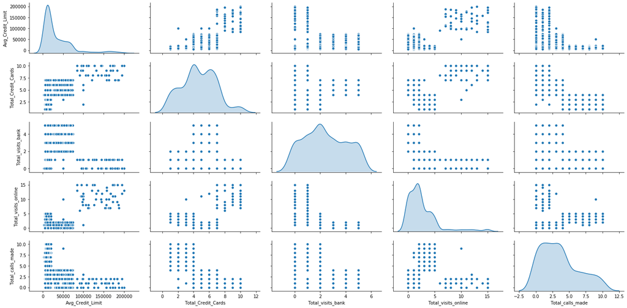

```python
sns.pairplot(data_attr, height=2,aspect=2 , diag_kind='kde')
```

Scaling and standardizing the data so that the variables with high peak values does not reduce the value of other variables. Scaling brings the mean to zero and dividing the data with standard deviation basically standardize the data by removing the "unit" of the distribution. This can be achieved by applying "zscore" formula over each numerical variable.

```python
data_attr_scaled = data_attr.apply(zscore)
```

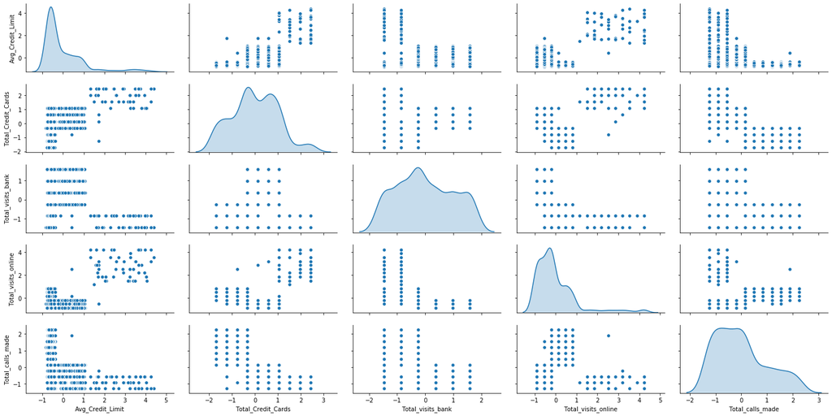

```python
sns.pairplot(data_attr_scaled, height=2,aspect=2 , diag_kind='kde')
```

From the above graphs specially the univariate ones, it can be seen that "Total Credit Cards" has obvious ripples and different peaks which means that they it can be divided into 2-3 different clusters. "Total visit bank" which is physical visits to bank and Online website visits also suggests that the data can be divided into 2-3 clusters. This observation can be confirmed by applying different clustering techniques and evaluating the quality of clusters formed.

Performing K-Mean Clustering and plotting. In the below code, average distortion is calculated. The "cdist" fuction here is going to calculate distance of every point with every centroid of a model. So the minimum will give distance of each point to the nearest centroid, then sum up the distances and take average to get "Average distortion" for each number of cluster.

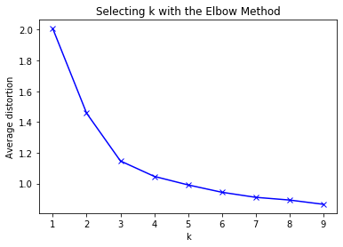

```python
#Finding optimal no. of clusters
from scipy.spatial.distance import cdist
clusters=range(1,10)
meanDistortions=[]

for k in clusters:
    model=KMeans(n_clusters=k)
    model.fit(data_attr_scaled)
    prediction=model.predict(data_attr_scaled)
    meanDistortions.append(sum(np.min(cdist(data_attr_scaled, model.cluster_centers_, 'euclidean'), axis=1)) / data_attr_scaled.shape[0])


plt.plot(clusters, meanDistortions, 'bx-')
plt.xlabel('k')
plt.ylabel('Average distortion')
plt.title('Selecting k with the Elbow Method')
```

From the above graph, it can be inferred that "3" is the transition point of the elbow. So, best option for this data set is to select "3" number of centroids.

```python
final_model=KMeans(3)
final_model.fit(data_attr_scaled)
prediction=final_model.predict(data_attr_scaled)

#Append the prediction
df["GROUP"] = prediction
data_attr_scaled["GROUP"] = prediction
print("Groups Assigned : \n")
df.head()
```

```
Groups Assigned :
```

|  | Sl_No | Customer Key | Avg_Credit_Limit | Total_Credit_Cards | Total_visits_bank | Total_visits_online | Total_calls_made | GROUP |
| --- | --- | --- | --- | --- | --- | --- | --- | --- |
| 0 | 1 | 87073 | 100000 | 2 | 1 | 1 | 0 | 0 |
| 1 | 2 | 38414 | 50000 | 3 | 0 | 10 | 9 | 2 |
| 2 | 3 | 17341 | 50000 | 7 | 1 | 3 | 4 | 0 |
| 3 | 4 | 40496 | 30000 | 5 | 1 | 1 | 4 | 0 |
| 4 | 5 | 47437 | 100000 | 6 | 0 | 12 | 3 | 1 |

```python
customer_clust = data_attr_scaled.groupby(['GROUP'])
customer_clust.mean()
```

| GROUP | Avg_Credit_Limit | Total_Credit_Cards | Total_visits_bank | Total_visits_online | Total_calls_made |
| --- | --- | --- | --- | --- | --- |
| 0 | -0.021062 | 0.373690 | 0.666395 | -0.553672 | -0.553005 |
| 1 | 2.831764 | 1.862226 | -1.105763 | 2.827319 | -0.874330 |
| 2 | -0.595796 | -1.059623 | -0.901518 | 0.322997 | 1.148109 |

```
array([[<matplotlib.axes._subplots.AxesSubplot object at 0x0000018A9C4C7DC8>,
      dtype=object)
```

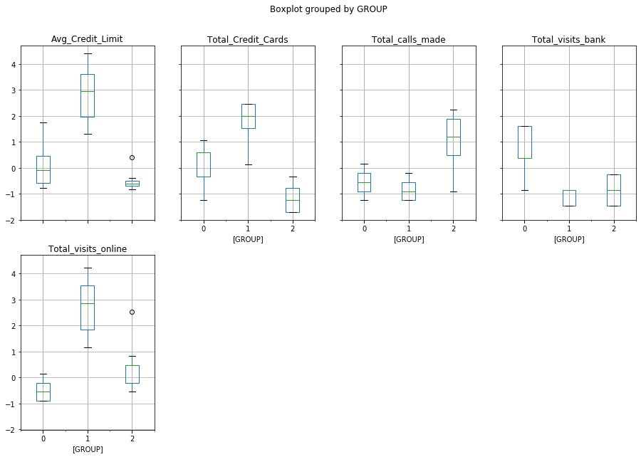

```python
data_attr_scaled.boxplot(by='GROUP', layout = (2,4),figsize=(15,10))
```

### Calculate Avg Silhoutte Score of K Means Clustering

```python
sillhouette_kmean=silhouette_score(data_attr_scaled,prediction)
```

# Heirarchical Clustering

```python
from scipy.cluster.hierarchy import cophenet, dendrogram, linkage
from scipy.spatial.distance import pdist  #Pairwise distribution between data points
```

## Average linkage

```python
#data_attr_scaled.drop(columns=['GROUP'],inplace=True)
Z = linkage(data_attr_scaled, metric='euclidean', method='average')
coph_avg, coph_dists = cophenet(Z , pdist(data_attr_scaled))

coph_avg
```

```
0.8977080867389372
```

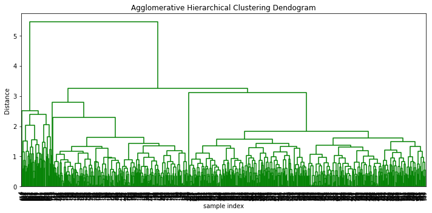

```python
plt.figure(figsize=(10, 5))
plt.title('Agglomerative Hierarchical Clustering Dendogram')
plt.xlabel('sample index')
plt.ylabel('Distance')
dendrogram(Z, leaf_rotation=90.,color_threshold = 40, leaf_font_size=8. )
plt.tight_layout()
```

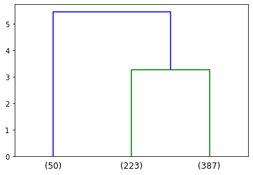

```python
# Hint: Use truncate_mode='lastp' attribute in dendrogram function to arrive at dendrogram
dendrogram(
    Z,
    truncate_mode='lastp',  # show only the last p merged clusters
    p=3,  # show only the last p merged clusters
)
plt.show()
```

```python
from scipy.cluster.hierarchy import fcluster
clust_avg_linkage = fcluster(Z, 3, criterion='maxclust')
clust_avg_linkage
```

```
array([3, 2, 3, 3, 1, 2, 1, 2, 2, 2, 2, 2, 2, 2, 2, 2, 2, 2, 2, 2, 2, 2,
       2, 2, 2, 2, 2, 2, 2, 2, 2, 2, 2, 2, 2, 2, 2, 2, 2, 2, 2, 2, 2, 2,
       2, 2, 2, 2, 2, 2, 2, 2, 2, 2, 2, 2, 2, 2, 2, 2, 2, 2, 2, 2, 2, 2,
       2, 2, 2, 2, 2, 2, 2, 2, 2, 2, 2, 2, 2, 2, 2, 2, 2, 2, 2, 2, 2, 2,
       2, 2, 2, 2, 2, 2, 2, 2, 2, 2, 2, 2, 2, 2, 2, 2, 2, 2, 2, 2, 2, 2,
       2, 2, 2, 2, 2, 2, 2, 2, 2, 2, 2, 2, 2, 2, 2, 2, 2, 2, 2, 2, 2, 2,
       2, 2, 2, 2, 2, 2, 2, 2, 2, 2, 2, 2, 2, 2, 2, 2, 2, 2, 2, 2, 2, 2,
       2, 2, 2, 2, 2, 2, 2, 2, 2, 2, 2, 2, 2, 2, 2, 2, 2, 2, 2, 2, 2, 2,
       2, 2, 2, 2, 2, 2, 2, 2, 2, 2, 2, 2, 2, 2, 2, 2, 2, 2, 2, 2, 2, 2,
       2, 2, 2, 2, 2, 2, 2, 2, 2, 2, 2, 2, 2, 2, 2, 2, 2, 2, 2, 2, 2, 2,
       2, 2, 2, 2, 2, 2, 2, 2, 3, 3, 3, 3, 3, 3, 3, 3, 3, 3, 3, 3, 3, 3,
       3, 3, 3, 3, 3, 3, 3, 3, 3, 3, 3, 3, 3, 3, 3, 3, 3, 3, 3, 3, 3, 3,
       3, 3, 3, 3, 3, 3, 3, 3, 3, 3, 3, 3, 3, 3, 3, 3, 3, 3, 3, 3, 3, 3,
       3, 3, 3, 3, 3, 3, 3, 3, 3, 3, 3, 3, 3, 3, 3, 3, 3, 3, 3, 3, 3, 3,
       3, 3, 3, 3, 3, 3, 3, 3, 3, 3, 3, 3, 3, 3, 3, 3, 3, 3, 3, 3, 3, 3,
```

[output cut: 16 more lines]

```python
# Calculate Avg Silhoutte Score

from sklearn.metrics import silhouette_score
sillhoutte_avg = silhouette_score(data_attr_scaled,clust_avg_linkage)
```

## Complete Linkage

```python
# cophenet index is a measure of the correlation between the distance of points in feature space and distance on dendrogram
# closer it is to 1, the better is the clustering

Z = linkage(data_attr_scaled, metric='euclidean', method='complete')
coph_complete, coph_dists = cophenet(Z , pdist(data_attr_scaled))

coph_complete
```

```
0.8599730607972423
```

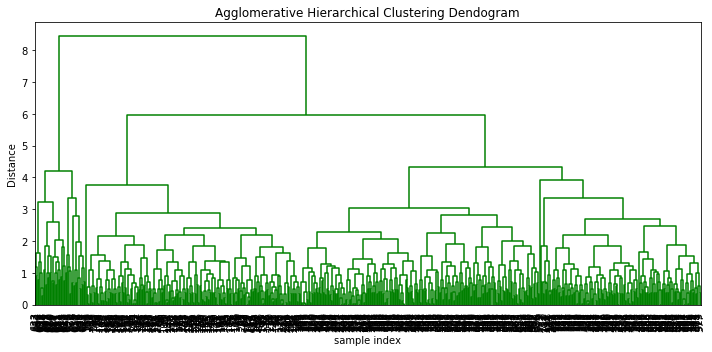

```python
plt.figure(figsize=(10, 5))
plt.title('Agglomerative Hierarchical Clustering Dendogram')
plt.xlabel('sample index')
plt.ylabel('Distance')
dendrogram(Z, leaf_rotation=90.,color_threshold=90,  leaf_font_size=10. )
plt.tight_layout()
```

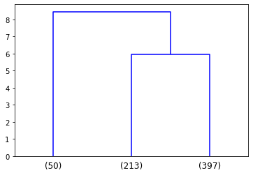

```python
# Hint: Use truncate_mode='lastp' attribute in dendrogram function to arrive at dendrogram
dendrogram(
    Z,
    truncate_mode='lastp',  # show only the last p merged clusters
    p=3,  # show only the last p merged clusters
)
plt.show()
```

```python
clust_complete_linkage = fcluster(Z, 3, criterion='maxclust')
clust_complete_linkage
```

```
array([3, 2, 3, 3, 1, 2, 1, 3, 3, 2, 2, 2, 2, 2, 2, 2, 2, 2, 2, 2, 2, 2,
       2, 2, 2, 2, 2, 2, 2, 2, 2, 2, 2, 2, 2, 2, 2, 2, 2, 2, 2, 2, 2, 2,
       2, 2, 2, 2, 2, 2, 2, 2, 2, 2, 2, 2, 2, 2, 2, 2, 2, 2, 2, 2, 2, 2,
       2, 2, 2, 2, 2, 2, 2, 2, 2, 2, 2, 2, 2, 2, 2, 2, 2, 2, 2, 2, 2, 3,
       2, 2, 2, 2, 2, 2, 2, 2, 2, 2, 2, 2, 2, 2, 2, 2, 2, 2, 2, 2, 2, 2,
       2, 2, 2, 3, 2, 2, 2, 2, 2, 2, 2, 2, 2, 2, 2, 2, 2, 2, 2, 2, 2, 3,
       3, 2, 2, 2, 2, 2, 2, 2, 2, 2, 2, 2, 2, 2, 2, 2, 2, 2, 2, 2, 2, 2,
       2, 2, 2, 2, 2, 2, 2, 2, 2, 2, 2, 2, 2, 2, 2, 2, 2, 2, 2, 2, 2, 2,
       2, 2, 2, 2, 2, 2, 2, 2, 3, 2, 2, 2, 2, 2, 2, 2, 3, 2, 2, 2, 2, 2,
       2, 2, 2, 2, 2, 2, 2, 2, 2, 2, 2, 2, 2, 2, 2, 2, 2, 2, 2, 3, 2, 2,
       2, 2, 2, 2, 2, 3, 2, 2, 3, 3, 3, 3, 3, 3, 3, 3, 3, 3, 3, 3, 3, 3,
       3, 3, 3, 3, 3, 3, 3, 3, 3, 3, 3, 3, 3, 3, 3, 3, 3, 3, 3, 3, 3, 3,
       3, 3, 3, 3, 3, 3, 3, 3, 3, 3, 3, 3, 3, 3, 3, 3, 3, 3, 3, 3, 3, 3,
       3, 3, 3, 3, 3, 3, 3, 3, 3, 3, 3, 3, 3, 3, 3, 3, 3, 3, 3, 3, 3, 3,
       3, 3, 3, 3, 3, 3, 3, 3, 3, 3, 3, 3, 3, 3, 3, 3, 3, 3, 3, 3, 3, 3,
```

[output cut: 16 more lines]

```python
# Calculate Avg Silhoutte Score

silhouette_complete = silhouette_score(data_attr_scaled,clust_complete_linkage)
```

## Ward Linkage

```python
# cophenet index is a measure of the correlation between the distance of points in feature space and distance on dendrogram
# closer it is to 1, the better is the clustering

Z = linkage(data_attr_scaled, metric='euclidean', method='ward')
coph_ward, coph_dists = cophenet(Z , pdist(data_attr_scaled))

coph_ward
```

```
0.7415156284827493
```

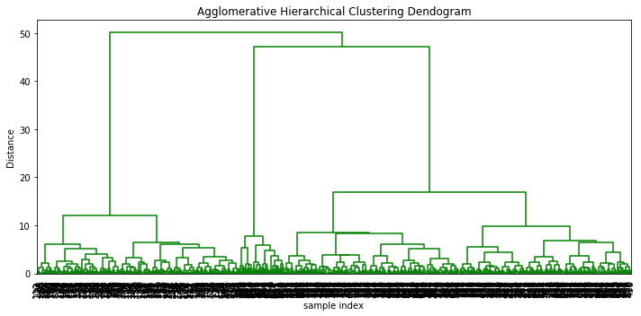

```python
plt.figure(figsize=(10, 5))
plt.title('Agglomerative Hierarchical Clustering Dendogram')
plt.xlabel('sample index')
plt.ylabel('Distance')
dendrogram(Z, leaf_rotation=90.,color_threshold=600,  leaf_font_size=10. )
plt.tight_layout()
```

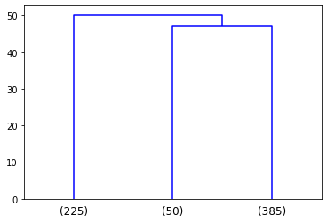

```python
# Hint: Use truncate_mode='lastp' attribute in dendrogram function to arrive at dendrogram
dendrogram(
    Z,
    truncate_mode='lastp',  # show only the last p merged clusters
    p=3,  # show only the last p merged clusters
)
plt.show()
```

```python
clust_ward_linkage = fcluster(Z, 3, criterion='maxclust')
clust_ward_linkage
```

```
array([3, 1, 3, 3, 2, 1, 2, 1, 1, 1, 1, 1, 1, 1, 1, 1, 1, 1, 1, 1, 1, 1,
       1, 1, 1, 1, 1, 1, 1, 1, 1, 1, 1, 1, 1, 1, 1, 1, 1, 1, 1, 1, 1, 1,
       1, 1, 1, 1, 1, 1, 1, 1, 1, 1, 1, 1, 1, 1, 1, 1, 1, 1, 1, 1, 1, 1,
       1, 1, 1, 1, 1, 1, 1, 1, 1, 1, 1, 1, 1, 1, 1, 1, 1, 1, 1, 1, 1, 1,
       1, 1, 1, 1, 1, 1, 1, 1, 1, 1, 1, 1, 1, 1, 1, 1, 1, 1, 1, 1, 1, 1,
       1, 1, 1, 1, 1, 1, 1, 1, 1, 1, 1, 1, 1, 1, 1, 1, 1, 1, 1, 1, 1, 1,
       1, 1, 1, 1, 1, 1, 1, 1, 1, 1, 1, 1, 1, 1, 1, 1, 1, 1, 1, 1, 1, 1,
       1, 1, 1, 1, 1, 1, 1, 1, 1, 1, 1, 1, 1, 1, 1, 1, 1, 1, 1, 1, 1, 1,
       1, 1, 1, 1, 1, 1, 1, 1, 1, 1, 1, 1, 1, 1, 1, 1, 1, 1, 1, 1, 1, 1,
       1, 1, 1, 1, 1, 1, 1, 1, 1, 1, 1, 1, 1, 1, 1, 1, 1, 1, 1, 1, 1, 1,
       1, 1, 1, 1, 1, 1, 1, 1, 3, 3, 3, 3, 3, 3, 3, 3, 3, 3, 3, 3, 3, 3,
       3, 3, 3, 3, 3, 3, 3, 3, 3, 3, 3, 3, 3, 3, 3, 3, 3, 3, 3, 3, 3, 3,
       3, 3, 3, 3, 3, 3, 3, 3, 3, 3, 3, 3, 3, 3, 3, 3, 3, 3, 3, 3, 3, 3,
       3, 3, 1, 3, 3, 3, 3, 3, 3, 3, 3, 3, 3, 3, 3, 3, 3, 3, 3, 3, 3, 3,
       3, 3, 3, 3, 3, 1, 3, 3, 3, 3, 3, 3, 3, 3, 3, 3, 3, 3, 3, 3, 3, 3,
```

[output cut: 16 more lines]

```python
# Calculate Avg Silhoutte Score

silhouette_ward = silhouette_score(data_attr_scaled,clust_ward_linkage)
```

```python
d= {'K mean':[sillhouette_kmean,np.nan],'Ward linkage':[silhouette_ward,coph_ward],'Average linkage':[sillhoutte_avg,coph_avg],'Complete linkage':[silhouette_complete,coph_complete]}
scores = pd.DataFrame(index=['Silhoutte score','Cophenetic Correlation'],data=d)
```

```python
scores
```

|  | K mean | Ward linkage | Average linkage | Complete linkage |
| --- | --- | --- | --- | --- |
| Silhoutte score | 0.515718 | 0.514764 | 0.515922 | 0.502644 |
| Cophenetic Correlation | NaN | 0.741516 | 0.897708 | 0.859973 |

From the above table, Heirarchical clustering with Average linkage has the best Sillhoutte score and cophenetic correlation. So we will now build box plot graph to have a look at the clusters.

```python
data_attr_scaled["GROUP"] = clust_avg_linkage
print("Groups Assigned : \n")
data_attr_scaled.head()
```

```
Groups Assigned :
```

|  | Avg_Credit_Limit | Total_Credit_Cards | Total_visits_bank | Total_visits_online | Total_calls_made | GROUP |
| --- | --- | --- | --- | --- | --- | --- |
| 0 | 1.740187 | -1.249225 | -0.860451 | -0.547490 | -1.251537 | 3 |
| 1 | 0.410293 | -0.787585 | -1.473731 | 2.520519 | 1.891859 | 2 |
| 2 | 0.410293 | 1.058973 | -0.860451 | 0.134290 | 0.145528 | 3 |
| 3 | -0.121665 | 0.135694 | -0.860451 | -0.547490 | 0.145528 | 3 |
| 4 | 1.740187 | 0.597334 | -1.473731 | 3.202298 | -0.203739 | 1 |

```python
customer_clust = data_attr_scaled.groupby(['GROUP'])
customer_clust.mean()
```

| GROUP | Avg_Credit_Limit | Total_Credit_Cards | Total_visits_bank | Total_visits_online | Total_calls_made |
| --- | --- | --- | --- | --- | --- |
| 1 | 2.831764 | 1.862226 | -1.105763 | 2.827319 | -0.874330 |
| 2 | -0.595179 | -1.062913 | -0.904453 | 0.325372 | 1.152605 |
| 3 | -0.022902 | 0.371882 | 0.664034 | -0.552775 | -0.551200 |

```
array([[<matplotlib.axes._subplots.AxesSubplot object at 0x0000018AA1BFF948>,
      dtype=object)
```

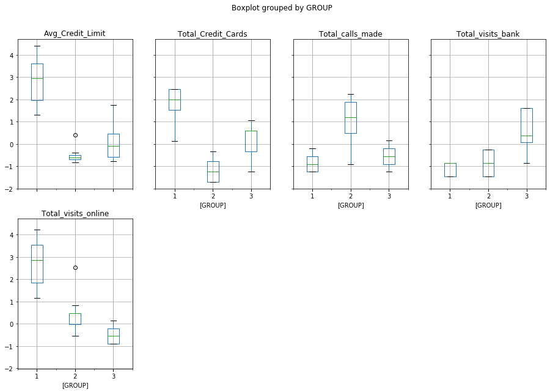

```python
data_attr_scaled.boxplot(by='GROUP', layout = (2,4),figsize=(15,10))
```

From the above graph we can have the below takeaways

1) Group 1 has high average credit limit and total credit cards count. They also tend to query bank via online method.

2) Group 2 has low average credit limit and total credit cards count. Group 2 customers also seems to contact bank via Call more often than the other groups.

### Comparison between Heirarchical clusters and K-Means clusters

From box plot, both clustering method seem to be agreeing on clusters formed. Both the clusters have grouped customers with high credit limit, high credit cards count and total online visits into one group. Both the clusters have grouped customers with low credit limit, low credit cards count and high calls made into one group. Both the clusters have group customers with relatively moderate credit limit, moderate credit cards count and high physical bank visits into one group.

## Recommendations to the bank

As per our cluster formations, we can see that the people with high credit card count and high limits prefer online mode of communication. These are the high value customers and must be provided best services. Online banking services must be enhanced, live chat options along with chatbot must be implemented. In case, a chatbot is being deployed, bank should make sure that customers get their queries resolved and appropriate first line support is provided at the instance. After that, customers with relatively moderate credit limit and moderate credit card count seems to be prefer physically visiting the bank. So, the bank should focus on improving the bank branches and provide special training to the bank representatives.  
Customer with low credit limits and low credit cards count seems to be liking the phone banking. So phone banking improvements must be considered by the bank as a lowes priority.

So the highest priority should be given in enhancing the online banking, then physical branches and then phone banking.